# Final

```python
from IPython.display import HTML
HTML('''
<script src='//code.jquery.com/jquery-3.3.1.min.js'></script>
<script>
code_show=true;
function code_toggle() {
 if (code_show){
 $('div.input').hide();
 $('div .jp-CodeCell .jp-Cell-inputWrapper').hide();
 } else {
 $('div.input').show();
 $('div .jp-CodeCell .jp-Cell-inputWrapper').show();
 }
 code_show = !code_show
}
$( document ).ready(code_toggle);
</script>
<form action="javascript:code_toggle()"><input type="submit" value="Code on/off"></form>''')
```

## Data Science Final Project-Global Military Expenditure For the Last Decade

#### Yanru Heng

https://github.com/hengyr/FinalProject.git

### Abstract

By looking into the coutries' expenditure from 2009-2018, the study found there's a correlation with GDP, region and income group of each country. Also the study cluster the numbers as a type of ranking showing USA and China both hold a specific tier while a few coutries like UK, France, India forms a third tier.

### Introduction and Background

Living in a time of globalization and information, military activities are becoming a less common but necessary elements for each country. By looking at these data we could analyze the "superpower" situation of the world. The dataset is from the world bank and also GDP data from world bank is also added in later questions. Generally we are trying to answer three major question:

1. By merging the GDP data of world bank dataset, what's the relationship between GDP situation related to the military expense? Is there necessarily a correlation? In another words, does a high GDP definitely reflect on a high military expense?
2. How should we classify the world miltary expense by clustering the expense situations of the last decade?
3. Considering percentage of GDP would go to military expenses for each country,are they generally even? Does different regions and income groups vary? Is there a correlation with GDP?

### Methods

The data contains military expense from 1960 to 2018. I only included the 2009-2018 data which is the last decade. As this should be a very professional and comprehensive data, missing values in this range would not be common for most major countries, I just excluded all the countries with missing values if in any column. 137 countries remained after cleaning which is still considerably sufficient and large enough to justify and world's situation.

A lot of python libraries were called to apply including Ipython.display, pandas,numpy, matplotlib.pyplot, matplotlib, seaborn, statistics, sklearn.preprocessing, sklearn.decomposition, and sklearn.cluster.

### Results

###### Q1

```python
fullgdp = pd.read_csv("/Users/yanru/Documents/DataSci/Assignments/Final/GDP.csv")
```

```python
gdp = pd.DataFrame(fullgdp,columns=['Country Name','Country Code','Indicator Name','2009','2010','2011','2012','2013','2014','2015','2016','2017','2018'])
#gdp.rename(columns={'2009': '2010'}, errors="raise")
gdp = gdp.dropna()
```

```python
expgdp = pd.merge(exp, gdp, left_on = 'Code', right_on = 'Country Code', how = 'left',suffixes=('_MilitaryExpenditure', '_GDP'))
#expgdp.columns[20]
expgdp["meanGDP"]=expgdp.iloc[:,20:].mean(axis=1)
expgdp= expgdp.set_index([expgdp['Name']])
```

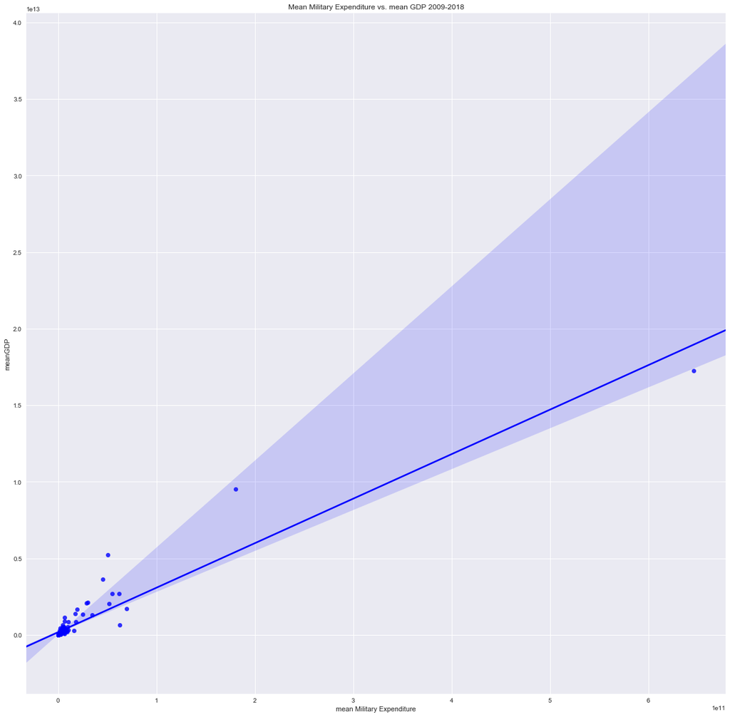

```python
expgdp["mean Military Expenditure"]=expgdp["mean"]
plt.figure(figsize=(20,20))
plot=sns.regplot(x=expgdp["mean Military Expenditure"],
            y=expgdp["meanGDP"],
            color="blue",
            fit_reg=True).set_title('Mean Military Expenditure vs. mean GDP 2009-2018')
#0.2 0.5 0.8
```

This graph answers question 1. Here we could see there does exist some correlation between mean GDP and mean military expenditures. And it is positive. However, the fit line has a large range. This may due to the outlier, USA. But excluding USA as an outlier is meaningless considering the real world situation. The general correlation should be even larger than the line drawn considering the shaow and USA is below the best fit line.

###### Q2

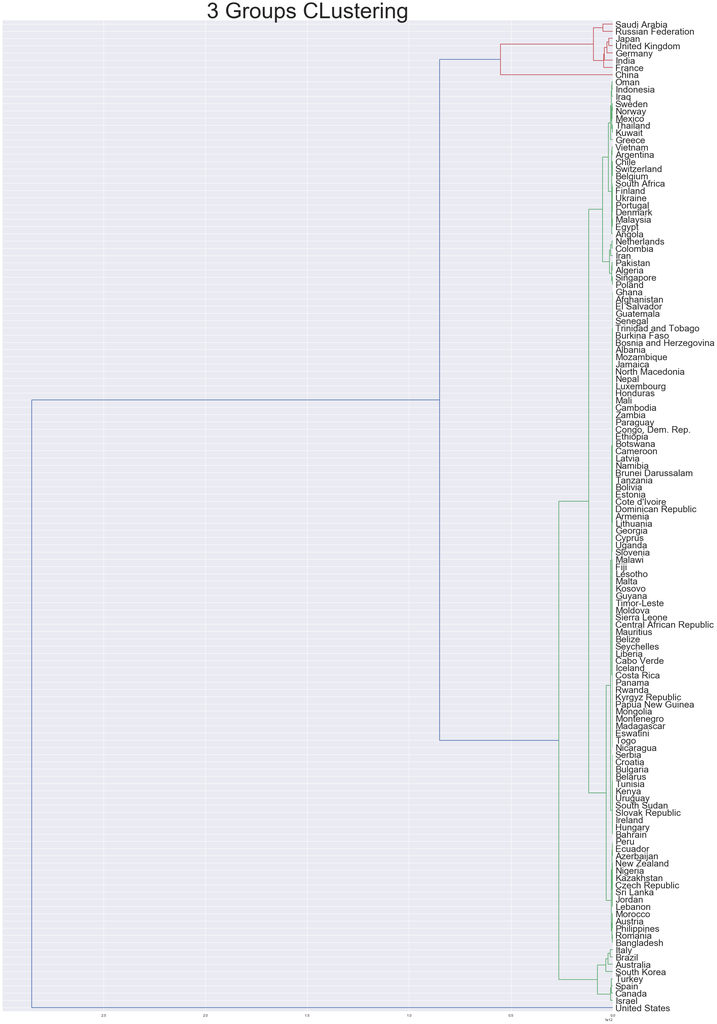

```python
import scipy.cluster.hierarchy as shc

plt.figure(figsize=(30, 50))
plt.title("3 Groups CLustering", fontsize=60)
dend = shc.dendrogram(shc.linkage(data, method='ward'),orientation="left", labels=data.index,show_contracted=True,
                      color_threshold=0.8e+12,leaf_font_size=25.)
```

```python
from sklearn.cluster import AgglomerativeClustering

cluster = AgglomerativeClustering(n_clusters=3, affinity='euclidean', linkage='ward')
n=cluster.fit_predict(data)

exp["cluster"]=n
print("Three Clustering Groups:","\n")
print("Group A:",exp[exp["cluster"]==1]['Region'],"\n")
print("Group B:",exp[exp["cluster"]==0]['Region'],"\n")
print("Group C shown in the graph","\n")
```

```
Three Clustering Groups:

Group A: Name
United States    North America
Name: Region, dtype: object

Group B: Name
China                        East Asia & Pacific
Germany                    Europe & Central Asia
France                     Europe & Central Asia
United Kingdom             Europe & Central Asia
India                                 South Asia
Japan                        East Asia & Pacific
Russian Federation         Europe & Central Asia
Saudi Arabia          Middle East & North Africa
Name: Region, dtype: object

Group C shown in the graph
```

For clustering, I used hierarchical clustering, after seeing the clustering, I could get the groups.In the dendrogram different colors represents different groupings.

The first one provides me with a 3-group clustering. Most noticeably, USA has its own tier. While countries like China, Gernmany, France, UK, India, Japan, Russia, Saudi Arabia forms the second tier and the rest is another group.

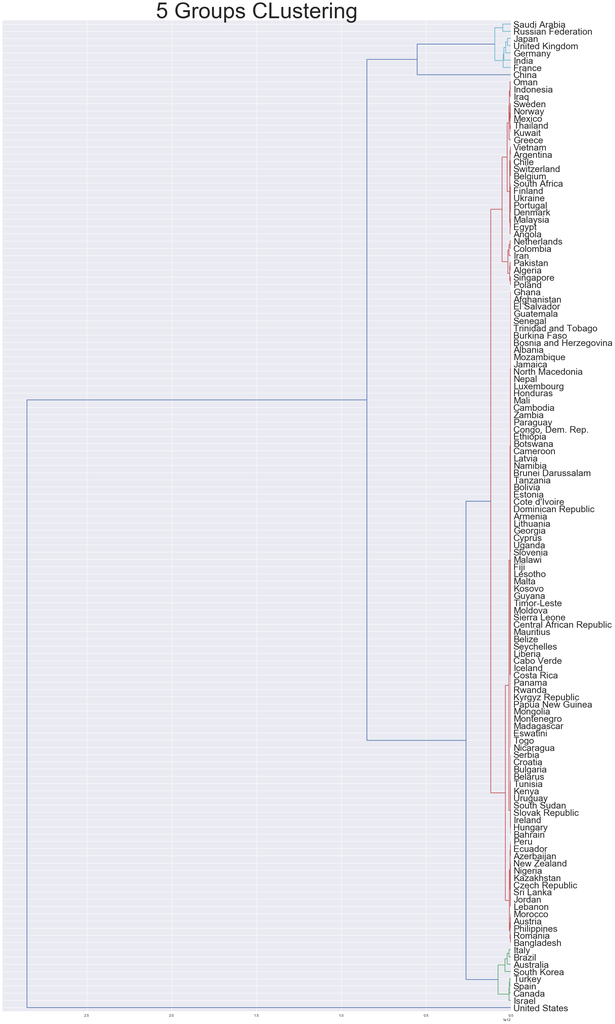

```python
plt.figure(figsize=(25, 50))
plt.title("5 Groups CLustering", fontsize=60)
dend = shc.dendrogram(shc.linkage(data, method='ward'),orientation="left", labels=data.index,show_contracted=True,
                      color_threshold=0.2e+12,leaf_font_size=25.)
```

```python
cluster = AgglomerativeClustering(n_clusters=5, affinity='euclidean', linkage='ward')
n=cluster.fit_predict(data)

exp["cluster"]=n
print("Five Clustering Groups:","\n")
print("Group A:",exp[exp["cluster"]==4]['Region'],"\n")
print("Group B:",exp[exp["cluster"]==3]['Region'],"\n")
print("Group C:",exp[exp["cluster"]==2]['Region'],"\n")
print("Group D:",exp[exp["cluster"]==1]['Region'],"\n")
#print("Group D shown in the graph","\n")
```

```
Five Clustering Groups:

Group A: Name
United States    North America
Name: Region, dtype: object

Group B: Name
China    East Asia & Pacific
Name: Region, dtype: object

Group C: Name
Germany                    Europe & Central Asia
France                     Europe & Central Asia
United Kingdom             Europe & Central Asia
India                                 South Asia
Japan                        East Asia & Pacific
Russian Federation         Europe & Central Asia
Saudi Arabia          Middle East & North Africa
Name: Region, dtype: object

Group D: Name
Australia             East Asia & Pacific
Brazil          Latin America & Caribbean
Canada                      North America
Spain               Europe & Central Asia
Israel         Middle East & North Africa
Italy               Europe & Central Asia
South Korea           East Asia & Pacific
Turkey              Europe & Central Asia
Name: Region, dtype: object
```

If the "cut-off" line moved a bit towards right,5 clusters would form. This is pretty much the same as the previous but with China form its own group leaving the others the same. And 8 countries formed another group from the majority. They are Australia, Brazil, Canada, Spain, Israel, Italy, South Korea, Turkey.

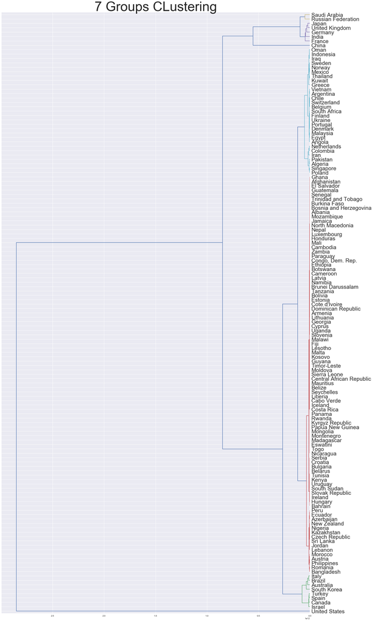

```python
plt.figure(figsize=(25, 50))
plt.title("7 Groups CLustering", fontsize=60)
dend = shc.dendrogram(shc.linkage(data, method='ward'),orientation="left", labels=data.index,show_contracted=True,
                      color_threshold=0.08e+12,leaf_font_size=25.)
```

```python
cluster = AgglomerativeClustering(n_clusters=7, affinity='euclidean', linkage='ward')
n=cluster.fit_predict(data)

exp["cluster"]=n
print("Sevevn Clustering Groups:","\n")
print("Group A:",exp[exp["cluster"]==6]['Region'],"\n")
print("Group B:",exp[exp["cluster"]==0]['Region'],"\n")
print("Group C:",exp[exp["cluster"]==4]['Region'],"\n")
print("Group D:",exp[exp["cluster"]==3]['Region'],"\n")
print("Group E:",exp[exp["cluster"]==2]['Region'],"\n")
print("Group F:",exp[exp["cluster"]==1]['Region'],"\n")
print("Group G which is the rest shown in the graph")
```

```
Sevevn Clustering Groups:

Group A: Name
Germany           Europe & Central Asia
France            Europe & Central Asia
United Kingdom    Europe & Central Asia
India                        South Asia
Japan               East Asia & Pacific
Name: Region, dtype: object

Group B: Name
Australia             East Asia & Pacific
Brazil          Latin America & Caribbean
Canada                      North America
Spain               Europe & Central Asia
Israel         Middle East & North Africa
Italy               Europe & Central Asia
South Korea           East Asia & Pacific
Turkey              Europe & Central Asia
Name: Region, dtype: object

Group C: Name
United States    North America
Name: Region, dtype: object

Group D: Name
China    East Asia & Pacific
Name: Region, dtype: object

Group E: Name
Angola                  Sub-Saharan Africa
Argentina        Latin America & Caribbean
Belgium              Europe & Central Asia
Switzerland          Europe & Central Asia
Chile            Latin America & Caribbean
Colombia         Latin America & Caribbean
Denmark              Europe & Central Asia
Algeria         Middle East & North Africa
Egypt           Middle East & North Africa
Finland              Europe & Central Asia
```

[output cut: 12 more lines]

```
Portugal             Europe & Central Asia
Singapore              East Asia & Pacific
Sweden               Europe & Central Asia
Thailand               East Asia & Pacific
Ukraine              Europe & Central Asia
Vietnam                East Asia & Pacific
South Africa            Sub-Saharan Africa
Name: Region, dtype: object

Group F: Name
Russian Federation         Europe & Central Asia
Saudi Arabia          Middle East & North Africa
Name: Region, dtype: object

Group G which is the rest shown in the graph
```

The last one I got is a 7 group clustering and the grouping is shown as above.

##### Q3

```python
expgdp['percent']=expgdp['mean']/expgdp['meanGDP']
```

```python
median3 = expgdp.groupby(["Region"])['percent'].aggregate(np.median).reset_index().sort_values('percent')
mean3 = expgdp.groupby(["Region"])['percent'].aggregate(np.mean).reset_index().sort_values('percent')
median4 = expgdp.groupby(["IncomeGroup"])['percent'].aggregate(np.median).reset_index().sort_values('percent')
mean4 = expgdp.groupby(["IncomeGroup"])['percent'].aggregate(np.mean).reset_index().sort_values('percent')
```

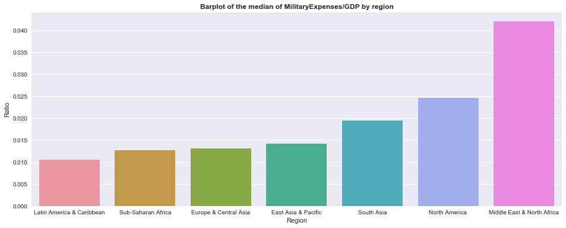

```python
plt.figure(figsize=(16,6))
sns.barplot(x='Region', y="percent", data= median3)
plt.title('Barplot of the median of MilitaryExpenses/GDP by region',fontweight="bold")
plt.xlabel('Region')
plt.ylabel('Ratio')
```

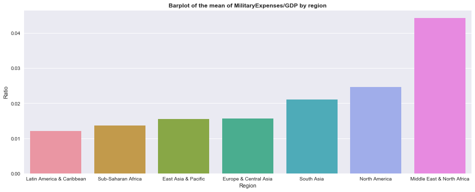

```python
plt.figure(figsize=(16,6))
sns.barplot(x='Region', y="percent", data= mean3)
plt.title('Barplot of the mean of MilitaryExpenses/GDP by region',fontweight="bold")
plt.xlabel('Region')
plt.ylabel('Ratio')
```

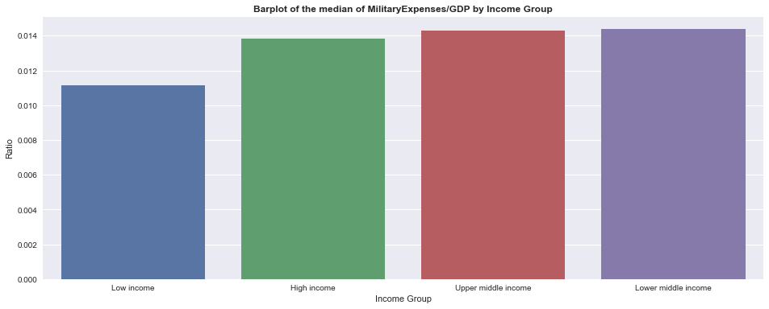

```python
plt.figure(figsize=(16,6))
sns.barplot(x='IncomeGroup', y="percent", data= median4)
plt.title('Barplot of the median of MilitaryExpenses/GDP by Income Group',fontweight="bold")
plt.xlabel('Income Group')
plt.ylabel('Ratio')
```

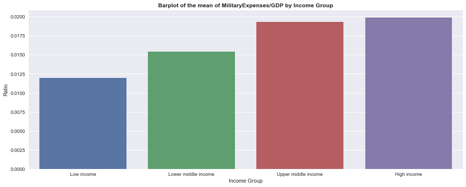

```python
plt.figure(figsize=(16,6))
sns.barplot(x='IncomeGroup', y="percent", data= mean4)
plt.title('Barplot of the mean of MilitaryExpenses/GDP by Income Group',fontweight="bold")
plt.xlabel('Income Group')
plt.ylabel('Ratio')
```

The plots show the median and mean of ratio of GDP contributes to GDP according to regions and income groups. Unlike the EDA showing the military expenditure grouped by regions and income groups in appendix, north america is not taking the lead. Middle East and North Africa is taking a significant lead which makes sense considering the state of peace in that area are usually at risk. Besides that, North America is still leading but not with much differences between region. If we look at the income groups, low income groups are less likely to use their GDP into military expenditure. While if we considerign the mean, low-middle income group is also considerably low.

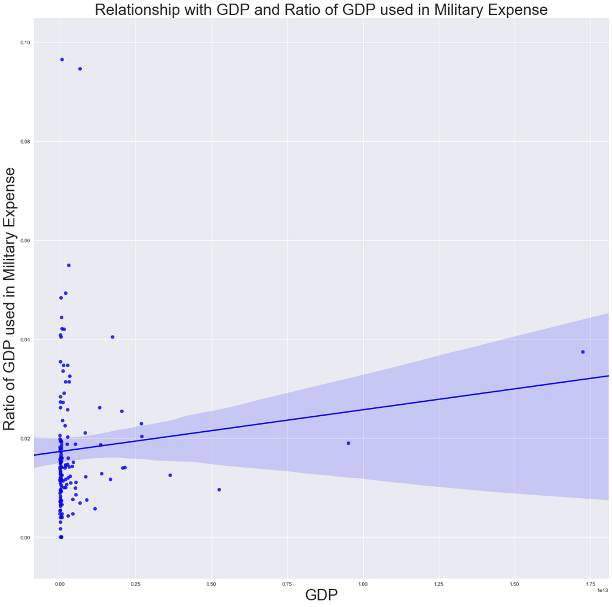

```python
plt.figure(figsize=(20,20))
plot=sns.regplot(x=expgdp["meanGDP"],
            y=expgdp["percent"],
            color="blue",
            fit_reg=True).set_title('Mean Military Expenditure vs. mean GDP')
plt.xlabel('GDP',fontsize=30)
plt.ylabel('Ratio of GDP used in Military Expense',fontsize=30)
plt.title('Relationship with GDP and Ratio of GDP used in Military Expense',fontsize=30 )
```

Generally I would say no matter the GDP is, the ratio is almost similar. although the fit line shows the slightly positive cases due to USA, The shadowing is very symmertric. At low ends of GDP, the ratio even varies largely. I would say region and income group are much influential varibales.

### Appendix

```python
import pandas as pd
import numpy as np
import matplotlib.pyplot as plt
import matplotlib as mpl
import seaborn as sns

%matplotlib inline
sns.set(color_codes=True)
```

```python
fullexp = pd.read_csv("/Users/yanru/Documents/DataSci/Assignments/Final/Military Expenditure.csv")
fullexp.head()
```

|  | Name | Code | Type | Indicator Name | 1960 | 1961 | 1962 | 1963 | 1964 | 1965 | ... | 2011 | 2012 | 2013 | 2014 | 2015 | 2016 | 2017 | 2018 | Region | IncomeGroup |
| --- | --- | --- | --- | --- | --- | --- | --- | --- | --- | --- | --- | --- | --- | --- | --- | --- | --- | --- | --- | --- | --- |
| 0 | Aruba | ABW | Country | Military expenditure (current USD) | NaN | NaN | NaN | NaN | NaN | NaN | ... | NaN | NaN | NaN | NaN | NaN | NaN | NaN | NaN | Latin America & Caribbean | High income |
| 1 | Afghanistan | AFG | Country | Military expenditure (current USD) | NaN | NaN | NaN | NaN | NaN | NaN | ... | 3.258070e+08 | 2.385834e+08 | 2.171941e+08 | 2.682271e+08 | 1.995186e+08 | 1.858783e+08 | 1.914071e+08 | 1.980863e+08 | South Asia | Low income |
| 2 | Angola | AGO | Country | Military expenditure (current USD) | NaN | NaN | NaN | NaN | NaN | NaN | ... | 3.639496e+09 | 4.144635e+09 | 6.090752e+09 | 6.841864e+09 | 3.608299e+09 | 2.764055e+09 | 3.062873e+09 | 1.983614e+09 | Sub-Saharan Africa | Lower middle income |
| 3 | Albania | ALB | Country | Military expenditure (current USD) | NaN | NaN | NaN | NaN | NaN | NaN | ... | 1.970068e+08 | 1.832047e+08 | 1.800155e+08 | 1.781204e+08 | 1.323507e+08 | 1.308532e+08 | 1.443827e+08 | 1.804887e+08 | Europe & Central Asia | Upper middle income |
| 4 | Andorra | AND | Country | Military expenditure (current USD) | NaN | NaN | NaN | NaN | NaN | NaN | ... | NaN | NaN | NaN | NaN | NaN | NaN | NaN | NaN | Europe & Central Asia | High income |

5 rows × 65 columns

This is our full set of data before cleaning.

```python
exp = pd.DataFrame(fullexp,columns=['Name','Code','Type','Indicator Name','2009','2010','2011','2012','2013','2014','2015','2016','2017','2018'])
exp['Region']=fullexp['Region']
exp['IncomeGroup']=fullexp['IncomeGroup']
exp = exp.dropna()
exp= exp.set_index([exp['Name']])
exp.head()
```

| Name | Name | Code | Type | Indicator Name | 2009 | 2010 | 2011 | 2012 | 2013 | 2014 | 2015 | 2016 | 2017 | 2018 | Region | IncomeGroup |
| --- | --- | --- | --- | --- | --- | --- | --- | --- | --- | --- | --- | --- | --- | --- | --- | --- |
| Afghanistan | Afghanistan | AFG | Country | Military expenditure (current USD) | 2.518695e+08 | 2.981469e+08 | 3.258070e+08 | 2.385834e+08 | 2.171941e+08 | 2.682271e+08 | 1.995186e+08 | 1.858783e+08 | 1.914071e+08 | 1.980863e+08 | South Asia | Low income |
| Angola | Angola | AGO | Country | Military expenditure (current USD) | 3.311193e+09 | 3.500795e+09 | 3.639496e+09 | 4.144635e+09 | 6.090752e+09 | 6.841864e+09 | 3.608299e+09 | 2.764055e+09 | 3.062873e+09 | 1.983614e+09 | Sub-Saharan Africa | Lower middle income |
| Albania | Albania | ALB | Country | Military expenditure (current USD) | 1.827369e+08 | 1.858932e+08 | 1.970068e+08 | 1.832047e+08 | 1.800155e+08 | 1.781204e+08 | 1.323507e+08 | 1.308532e+08 | 1.443827e+08 | 1.804887e+08 | Europe & Central Asia | Upper middle income |
| Argentina | Argentina | ARG | Country | Military expenditure (current USD) | 2.981852e+09 | 3.475348e+09 | 4.051930e+09 | 4.563218e+09 | 5.137974e+09 | 4.979443e+09 | 5.482617e+09 | 4.509648e+09 | 5.459644e+09 | 4.144992e+09 | Latin America & Caribbean | Upper middle income |
| Armenia | Armenia | ARM | Country | Military expenditure (current USD) | 3.594993e+08 | 3.950115e+08 | 3.908714e+08 | 3.805717e+08 | 4.445519e+08 | 4.578070e+08 | 4.473798e+08 | 4.313962e+08 | 4.436104e+08 | 6.088546e+08 | Europe & Central Asia | Upper middle income |

This is the cleaned data with 137 countries left.

```python
exp.describe()
```

|  | 2009 | 2010 | 2011 | 2012 | 2013 | 2014 | 2015 | 2016 | 2017 | 2018 | mean | cluster |
| --- | --- | --- | --- | --- | --- | --- | --- | --- | --- | --- | --- | --- |
| count | 1.370000e+02 | 1.370000e+02 | 1.370000e+02 | 1.370000e+02 | 1.370000e+02 | 1.370000e+02 | 1.370000e+02 | 1.370000e+02 | 1.370000e+02 | 1.370000e+02 | 1.370000e+02 | 137.000000 |
| mean | 1.102216e+10 | 1.161730e+10 | 1.236894e+10 | 1.237358e+10 | 1.234579e+10 | 1.239052e+10 | 1.185263e+10 | 1.177973e+10 | 1.223720e+10 | 1.289584e+10 | 1.208837e+10 | 4.029197 |
| std | 5.852786e+10 | 6.112444e+10 | 6.267255e+10 | 6.090043e+10 | 5.777711e+10 | 5.599239e+10 | 5.499104e+10 | 5.523285e+10 | 5.615509e+10 | 6.015038e+10 | 5.813299e+10 | 1.658053 |
| min | 0.000000e+00 | 0.000000e+00 | 0.000000e+00 | 0.000000e+00 | 0.000000e+00 | 0.000000e+00 | 0.000000e+00 | 0.000000e+00 | 0.000000e+00 | 0.000000e+00 | 0.000000e+00 | 0.000000 |
| 25% | 1.444346e+08 | 1.678579e+08 | 1.970068e+08 | 1.966615e+08 | 2.111760e+08 | 2.181184e+08 | 1.995186e+08 | 1.617519e+08 | 1.910658e+08 | 2.184443e+08 | 2.079851e+08 | 2.000000 |
| 50% | 7.988686e+08 | 7.720851e+08 | 8.290318e+08 | 8.536226e+08 | 9.569526e+08 | 9.133685e+08 | 8.436678e+08 | 7.554065e+08 | 8.241870e+08 | 1.030417e+09 | 8.564616e+08 | 5.000000 |
| 75% | 4.017404e+09 | 4.407286e+09 | 4.973864e+09 | 4.592165e+09 | 5.529879e+09 | 5.191509e+09 | 4.818121e+09 | 4.796011e+09 | 5.093789e+09 | 5.227152e+09 | 4.994894e+09 | 5.000000 |
| max | 6.690000e+11 | 6.980000e+11 | 7.110000e+11 | 6.850000e+11 | 6.400000e+11 | 6.100000e+11 | 5.960000e+11 | 6.000000e+11 | 6.060000e+11 | 6.490000e+11 | 6.464000e+11 | 6.000000 |

This shows the statistics for each year.

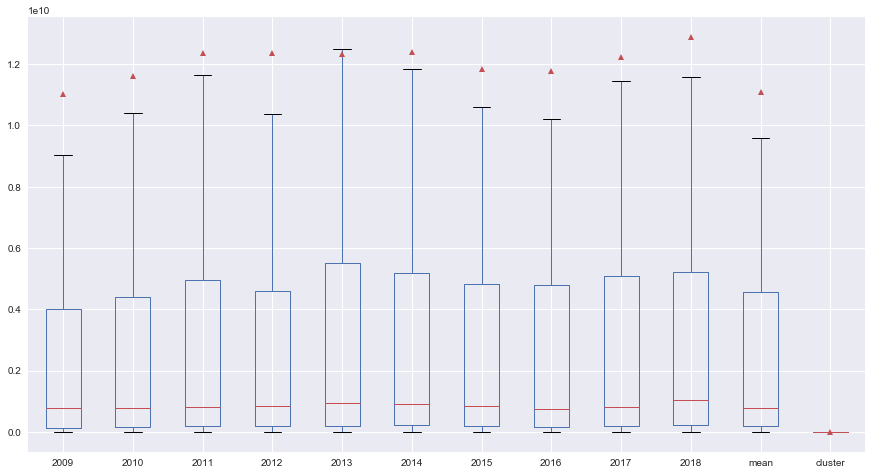

```python
plt.figure(figsize=(15,8))
exp.boxplot(showfliers=False,showmeans=True)
```

Putting the statistics in each year, red triangle dot shows the mean expenditure of the 137 countries in that year. Rests are nomal boxplot with percentiles, min, max. I excludes the residuals as there are so many. And interestingly we can see the mean are almost all out of the range besids 2013 came just close. It shows the a few powerful countries spent the most of military expenditures.

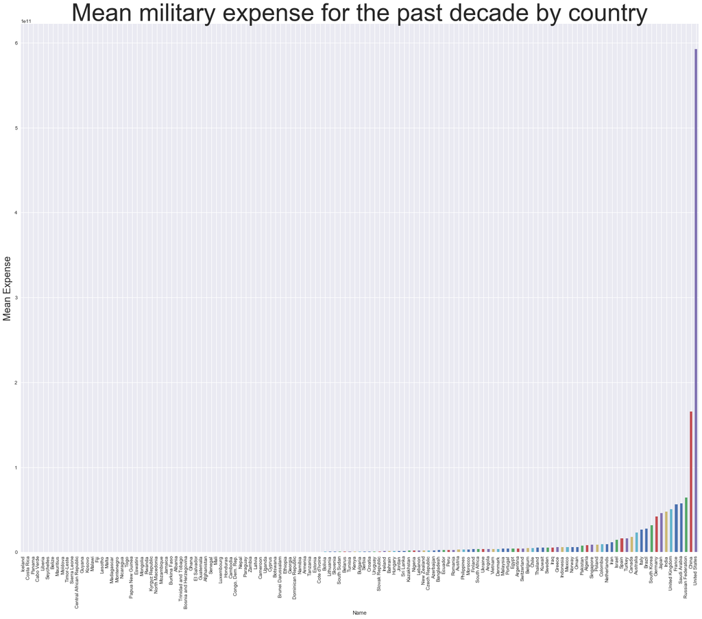

```python
import statistics
exp["mean"]=exp.iloc[:,4:].mean(axis=1)
exp["mean"].sort_values().plot(kind="bar", figsize=[25,20])
plt.ylabel('Mean Expense',fontsize=20)
plt.title('Mean military expense for the past decade by country',fontsize=50)
```

Here I calculated the mean military expenditure per years spent by each country and ranked them and put them in the bar plot. We can see USA is leading the world while China comes second surpass Russia which is the third a lot. But adding China and Russia together is still less than USA.

```python
median1 = exp.groupby(["Region"])['mean'].aggregate(np.median).reset_index().sort_values('mean')
print("Median of means by Region:")
median1
#median by Region mean
```

```
Median of means by Region:
```

|  | Region | mean |
| --- | --- | --- |
| 6 | Sub-Saharan Africa | 2.278693e+08 |
| 2 | Latin America & Caribbean | 2.945435e+08 |
| 1 | Europe & Central Asia | 1.447493e+09 |
| 5 | South Asia | 1.906661e+09 |
| 0 | East Asia & Pacific | 3.598648e+09 |
| 3 | Middle East & North Africa | 4.602020e+09 |
| 4 | North America | 3.052111e+11 |

```python
mean1 = exp.groupby(["Region"])['mean'].aggregate(np.mean).reset_index().sort_values('mean')
print("Mean of means by Region:")
mean1
```

```
Mean of means by Region:
```

|  | Region | mean |
| --- | --- | --- |
| 6 | Sub-Saharan Africa | 4.872686e+08 |
| 2 | Latin America & Caribbean | 2.857352e+09 |
| 1 | Europe & Central Asia | 7.658431e+09 |
| 3 | Middle East & North Africa | 8.680467e+09 |
| 5 | South Asia | 9.935663e+09 |
| 0 | East Asia & Pacific | 1.759631e+10 |
| 4 | North America | 3.052111e+11 |

[figure not shown]

```python
plt.figure(figsize=(16,6))
sns.barplot(x='Region', y="mean", data= median1)
plt.title('Barplot of the median of mean expenses by region',fontweight="bold")
plt.xlabel('Region')
plt.ylabel('Median of mean expenses')
```

[figure not shown]

```python
plt.figure(figsize=(16,6))
sns.barplot(x='Region', y="mean", data= mean1)
plt.title('Barplot of the mean of mean expenses by region',fontweight="bold")
plt.xlabel('Region')
plt.ylabel('Mean of mean expenses')
```

```python
median2 = exp.groupby(["IncomeGroup"])['mean'].aggregate(np.median).reset_index().sort_values('mean')
print("Median of means by Income Group:")
median2
#median by Region mean
```

```
Median of means by Income Group:
```

|  | IncomeGroup | mean |
| --- | --- | --- |
| 1 | Low income | 1.541699e+08 |
| 2 | Lower middle income | 3.458508e+08 |
| 3 | Upper middle income | 1.151758e+09 |
| 0 | High income | 3.902685e+09 |

```python
mean2 = exp.groupby(["IncomeGroup"])['mean'].aggregate(np.mean).reset_index().sort_values('mean')
print("Mean of means by Income Group:")
mean2
```

```
Mean of means by Income Group:
```

|  | IncomeGroup | mean |
| --- | --- | --- |
| 1 | Low income | 2.003252e+08 |
| 2 | Lower middle income | 2.934234e+09 |
| 3 | Upper middle income | 8.402741e+09 |
| 0 | High income | 2.278331e+10 |

[figure not shown]

```python
plt.figure(figsize=(16,6))
sns.barplot(x='IncomeGroup', y="mean", data= median2)
plt.title('Barplot of the median of mean expenses by Income Group',fontweight="bold")
plt.xlabel('IncomeGroup')
plt.ylabel('Median of mean expenses')
```

[figure not shown]

```python
plt.figure(figsize=(16,6))
sns.barplot(x='IncomeGroup', y="mean", data= mean2)
plt.title('Barplot of the mean of mean expenses by Income Group',fontweight="bold")
plt.xlabel('IncomeGroup')
plt.ylabel('Mean of mean expenses')
```

From the two charts and two plots visualizing them. We could see both mean and median of the means of the military expenditure over the past decade goes exactly as the income situation. Better the income status, better the military expenses.

```python
fullgdp = pd.read_csv("/Users/yanru/Documents/DataSci/Assignments/Final/GDP.csv")
```

[output not shown]

5 rows × 64 columns

This is the unclean data of GDP.

```python
gdp = pd.DataFrame(fullgdp,columns=['Country Name','Country Code','Indicator Name','2009','2010','2011','2012','2013','2014','2015','2016','2017','2018'])
#gdp.rename(columns={'2009': '2010'}, errors="raise")

gdp = gdp.dropna()
```

```python
expgdp = pd.merge(exp, gdp, left_on = 'Code', right_on = 'Country Code', how = 'left',suffixes=('_MilitaryExpenditure', '_GDP'))
#expgdp.columns[20]
expgdp["meanGDP"]=expgdp.iloc[:,20:].mean(axis=1)
expgdp= expgdp.set_index([expgdp['Name']])
expgdp.head()
```

| Name | Name | Code | Type | Indicator Name_MilitaryExpenditure | 2009_MilitaryExpenditure | 2010_MilitaryExpenditure | 2011_MilitaryExpenditure | 2012_MilitaryExpenditure | 2013_MilitaryExpenditure | 2014_MilitaryExpenditure | ... | 2010_GDP | 2011_GDP | 2012_GDP | 2013_GDP | 2014_GDP | 2015_GDP | 2016_GDP | 2017_GDP | 2018_GDP | meanGDP |
| --- | --- | --- | --- | --- | --- | --- | --- | --- | --- | --- | --- | --- | --- | --- | --- | --- | --- | --- | --- | --- | --- |
| Afghanistan | Afghanistan | AFG | Country | Military expenditure (current USD) | 2.518695e+08 | 2.981469e+08 | 3.258070e+08 | 2.385834e+08 | 2.171941e+08 | 2.682271e+08 | ... | 1.585657e+10 | 1.780428e+10 | 2.000162e+10 | 2.056105e+10 | 2.048487e+10 | 1.990711e+10 | 1.936264e+10 | 2.019176e+10 | 1.936297e+10 | 1.859720e+10 |
| Angola | Angola | AGO | Country | Military expenditure (current USD) | 3.311193e+09 | 3.500795e+09 | 3.639496e+09 | 4.144635e+09 | 6.090752e+09 | 6.841864e+09 | ... | 8.379950e+10 | 1.117900e+11 | 1.280530e+11 | 1.367100e+11 | 1.457120e+11 | 1.161940e+11 | 1.011240e+11 | 1.221240e+11 | 1.057510e+11 | 1.121565e+11 |
| Albania | Albania | ALB | Country | Military expenditure (current USD) | 1.827369e+08 | 1.858932e+08 | 1.970068e+08 | 1.832047e+08 | 1.800155e+08 | 1.781204e+08 | ... | 1.192695e+10 | 1.289087e+10 | 1.231978e+10 | 1.277628e+10 | 1.322825e+10 | 1.138693e+10 | 1.186135e+10 | 1.302506e+10 | 1.505888e+10 | 1.265186e+10 |
| Argentina | Argentina | ARG | Country | Military expenditure (current USD) | 2.981852e+09 | 3.475348e+09 | 4.051930e+09 | 4.563218e+09 | 5.137974e+09 | 4.979443e+09 | ... | 4.236270e+11 | 5.301630e+11 | 5.459820e+11 | 5.520250e+11 | 5.263200e+11 | 5.947490e+11 | 5.575310e+11 | 6.426960e+11 | 5.184750e+11 | 5.224544e+11 |
| Armenia | Armenia | ARM | Country | Military expenditure (current USD) | 3.594993e+08 | 3.950115e+08 | 3.908714e+08 | 3.805717e+08 | 4.445519e+08 | 4.578070e+08 | ... | 9.260285e+09 | 1.014211e+10 | 1.061932e+10 | 1.112147e+10 | 1.160951e+10 | 1.055334e+10 | 1.054614e+10 | 1.152746e+10 | 1.243309e+10 | 1.064607e+10 |

5 rows × 31 columns

This is the merged and cleaned data containing gdp over the past decade.

```python
from sklearn.preprocessing import StandardScaler
scaler=StandardScaler()
data = pd.DataFrame(exp,columns=['2009','2010','2011','2012','2013','2014','2015','2016','2017','2018'])
data = data.set_index([exp['Name']])
scaler.fit(data)
data_scaled=scaler.transform(data)

from sklearn.decomposition import PCA
pca = PCA(n_components=3)
pca.fit(data_scaled)
pca_scores=pca.fit_transform(data_scaled)
#pd.DataFrame(pca_scores).shape
```

[output not shown]

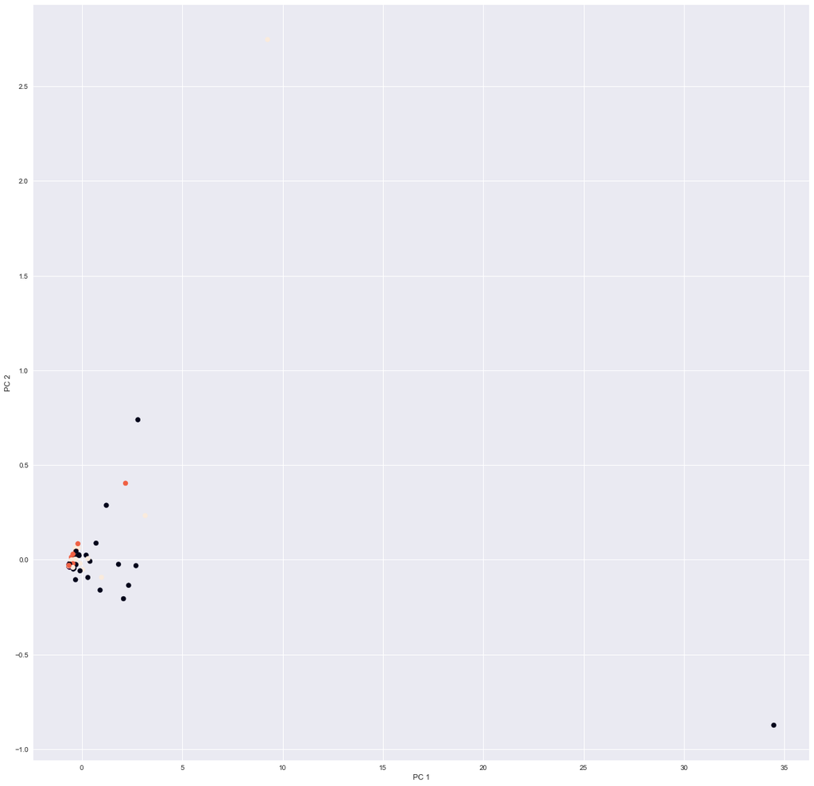

```python
from sklearn.preprocessing import LabelEncoder
LE=LabelEncoder()
plt.figure(figsize=(20,20))
plt.scatter(pca_scores[:,0], pca_scores[:,1], c=LE.fit_transform(exp['IncomeGroup']))
plt.xlabel('PC 1')
plt.ylabel('PC 2')
```

[output not shown]

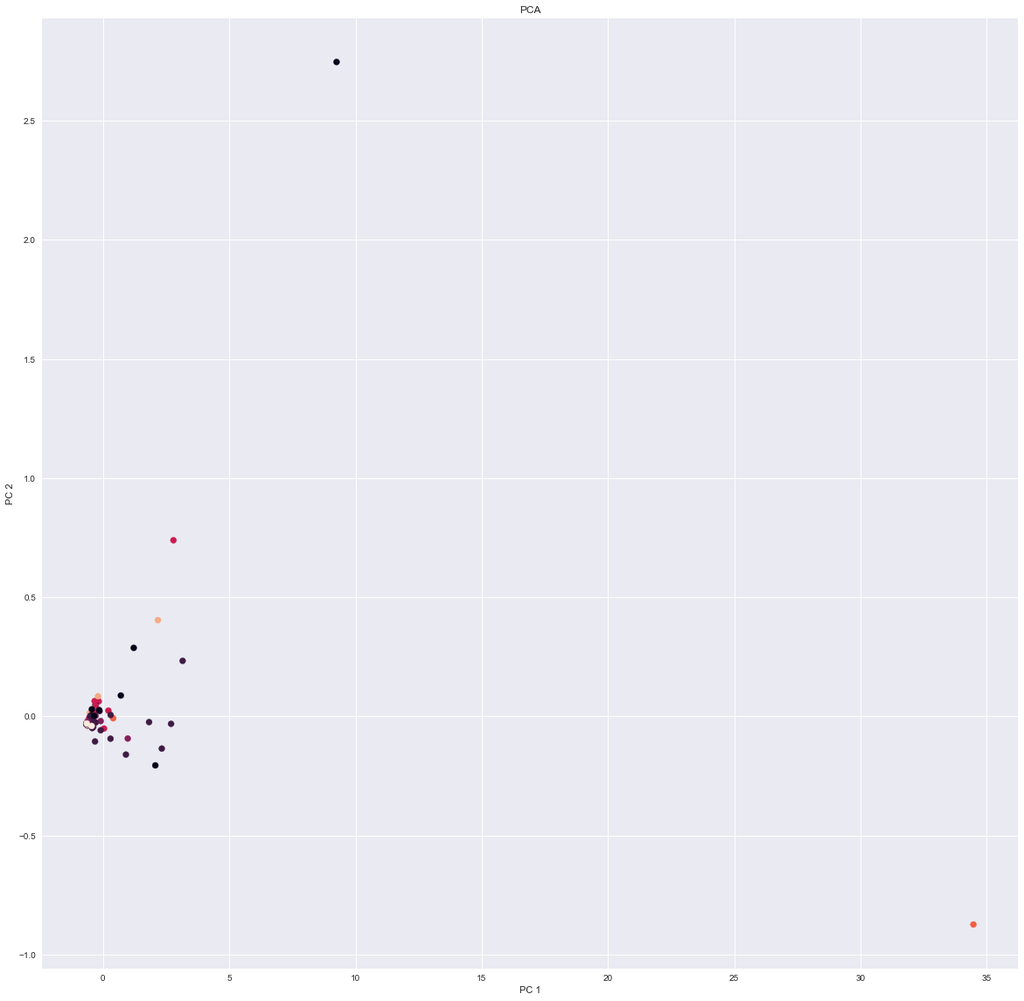

```python
plt.figure(figsize=(20,20))
plt.scatter(pca_scores[:,0], pca_scores[:,1], c=LE.fit_transform(exp['Region']))
plt.xlabel('PC 1')
plt.ylabel('PC 2')
plt.title("PCA")
plt.show
```

Here are the two PCAs I got after scaling. The color in the first graph shows the income group and the second one is regions. However, there are so many overlapping and hard to group them so I used the hierachy clustering as in the results show.